# Severe Heat Days using the Universal Thermal Comfort Index

#### 🗺️ Map 2: Municipal Heat Days

We visualize how the number of extreme heat days varies across municipalities. This map displays the total number of severe heat days (≥32°C) in each municipality.

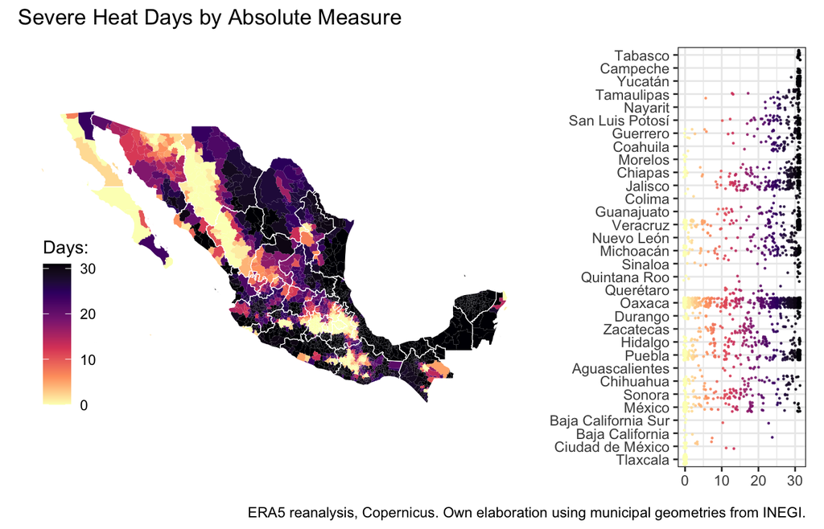

```r
# Map
mapa |>
    rename(CVEGEO = cvegeo) |>
  left_join(UTCI_mun_summary |>
      mutate(CVEGEO = str_pad(CVEGEO, width = 5,
                            side = "left", pad = "0")),
  by = c("CVEGEO")) |>
    # Plot:
    ggplot() +
  geom_sf(aes(fill = Absoluto), color = NA) +
  geom_sf(data = mapa2, fill = NA, color = "white", linewidth = 0.2) +
  scale_fill_viridis_c(option = "magma",
                       direction = -1,
                       name = "Days:") +
    theme_void() +
    theme(legend.position = c(.1,.3),
          plot.background = element_rect(fill = "white",
                                         color = "white"),
          plot.margin = unit(c(.2, .2, .2, .2),
                             "cm"))+
# Jitter plot
mapa |>
    rename(CVEGEO = cvegeo) |>
  left_join(UTCI_mun_summary |>
      mutate(CVEGEO = str_pad(CVEGEO, width = 5,
                            side = "left", pad = "0")),
  by = c("CVEGEO")) |>
    st_drop_geometry() |>
    left_join(mapa2 |>
                 clean_names() |>
                  rename(name_state = nomgeo),
              by = "cve_ent") |>
    group_by(name_state) |>
    mutate(MeanAbs = mean(Absoluto, na.rm = T)) |>
    ggplot() +
  geom_jitter(aes(x = Absoluto,
                  y = fct_reorder(name_state, MeanAbs),
                  group = name_state,
      color = Absoluto),
      size = .17,
      alpha = .8) +
  scale_color_viridis_c(option = "magma",
                       direction = -1,
                       name = "Days:") +
    theme_bw() +
    theme(legend.position = "none")+
    labs(x = NULL, y = NULL)+
    plot_layout(widths = c(4,1))+
    plot_annotation(title = "Severe Heat Days by Absolute Measure",
                    caption = "ERA5 reanalysis, Copernicus. Own elaboration using municipal geometries from INEGI.")
```

## Final Remarks

By focusing on an absolute threshold (UTCI ≥ 32°C), this entry lays the groundwork for internationally comparable indicators of heat exposure. Future work will expand on these foundations by incorporating relative thresholds, population vulnerability, and health system capacity.

This Code & Data entry is part of ongoing research by the CACHE initiative, and aims to promote transparency, reproducibility, and collaboration around climate-demographic methods.

## Footnotes

[^1]: Di Napoli C., Barnard C., Prudhomme C., Cloke HL and Pappenberger F. (2020): Thermal comfort indices derived from ERA5 reanalysis. Copernicus Climate Change Service (C3S) Climate Data Store (CDS). DOI: 10.24381/cds.553b7518 (Accessed on 01-11-2024)